# Analyses et figures de l’expérience 1 - thèse : Répétition, division e l’attention et crédibilité

Jérémy Béna

15 janvier 2017

Ce document présente les principales analyses et figures produites avec R présentées dans le document principal style article. J’essaie de faire ressortir les principaux résultats par des commentaires.

Le code utilisé est disponible dans le document script_traitement.R. Certains morceaux de code ont été laissés ici dans l’eventualité où connaître les détails des analyses serait utile pour en comprendre les résultats.

# Analyses

## Répliquer l’effet de vérité

On peut tout d’abord tester si on a répliqué l’effet de vérité

```r
#One sample t test (test value = 0) on the truth judgement score

t.test(data$diff_prop_rn,mu = 0) #Main test
```

```
    One Sample t-test

data:  data$diff_prop_rn
t = 5.2659, df = 185, p-value = 3.847e-07
alternative hypothesis: true mean is not equal to 0
95 percent confidence interval:
 0.04334723 0.09528564
sample estimates:
 mean of x
0.06931644
```

```r
cohensD(data$diff_prop_rn,mu=0) #Effect size with Cohen's d
```

```
[1] 0.3861175
```

```r
##95%CI were computed with JASP
```

L’effet de vérité a été montré comme statistiquement significatif. Sa taille d’effet est petite.

## Scores de mémoire

### Mémoire de source : variations en fonction des conditions expérimentales

J’ai réalisé une ANOVA 2(liste) x 2(attention) x 2(crédibilité) sur le score de mémoire de source.

```r
#Compute the 2*2*2 ANOVA on the source memory score

aov_sourcememory = ezANOVA(data = data_attrib
                                , dv = value
                                , wid = ppt
                                , within = attrib
                                , between = .(manip_attention,manip_cred)
                                , return_aov = TRUE
                                , detailed = TRUE
                                , type = 3
)
#df2 = n-N-k

aov_sourcememory
```

```
$ANOVA
                             Effect DFn DFd          SSn       SSd
1                       (Intercept)   1 182 1.179027e+02  6.866054
2                   manip_attention   1 182 7.705015e-02  6.866054
3                        manip_cred   1 182 1.044148e+00  6.866054
5                            attrib   1 182 1.142477e-01 15.741310
4        manip_attention:manip_cred   1 182 1.150881e-02  6.866054
6            manip_attention:attrib   1 182 6.387491e-03 15.741310
7                 manip_cred:attrib   1 182 1.786514e+00 15.741310
8 manip_attention:manip_cred:attrib   1 182 4.234330e-02 15.741310
             F             p p<.05          ges
1 3.125273e+03 1.507238e-116     * 0.8391050326
2 2.042385e+00  1.546837e-01       0.0033966121
3 2.767747e+01  3.999113e-07     * 0.0441472081
5 1.320924e+00  2.519343e-01       0.0050281509
4 3.050666e-01  5.814011e-01       0.0005088145
6 7.385176e-02  7.861170e-01       0.0002824605
7 2.065556e+01  9.996937e-06     * 0.0732361703
8 4.895705e-01  4.850123e-01       0.0018694856

$aov

Call:
aov(formula = formula(aov_formula), data = data)

Grand Mean: 0.5630691

Stratum 1: ppt

Terms:
                manip_attention manip_cred manip_attention:manip_cred
Sum of Squares         0.083280   1.044148                   0.011509
Deg. of Freedom               1          1                          1
                Residuals
Sum of Squares   6.866054
Deg. of Freedom       182

Residual standard error: 0.1942307
3 out of 6 effects not estimable
Estimated effects may be unbalanced

Stratum 2: ppt:attrib

Terms:
                   attrib manip_attention:attrib manip_cred:attrib
Sum of Squares   0.115762               0.004297          1.786514
Deg. of Freedom         1                      1                 1
                manip_attention:manip_cred:attrib Residuals
Sum of Squares                           0.042343 15.741310
Deg. of Freedom                                 1       182

Residual standard error: 0.294093
Estimated effects may be unbalanced
```

La crédibilité a montré un effet significatif. Cet effet a été qualifié par un effet d’interaction significatif entre la crédibilité et la liste (appelée “attrib”“). Des contrastes avec correction de bonferroni ont été calculés afin d’analyser les différences 2 à 2 (avec tailles des effets cohen’s D)

```r
##Modèle pour calculer les comparaisons multiples
###Comparaisons multiples pour chaque variable
lm_aov_source = lm(value~attrib+manip_attention+manip_cred,data=data_attrib)

k1 = glht(lm_aov_source, mcp(attrib = "Tukey"))$linfct
k2 = glht(lm_aov_source, mcp(manip_attention = "Tukey"))$linfct
k3 = glht(lm_aov_source, mcp(manip_cred = "Tukey"))$linfct
summary(glht(lm_aov_source,linfct=rbind(k1,k2,k3)), test = adjusted(type = "bonferroni"))
```

```
     Simultaneous Tests for General Linear Hypotheses

Fit: lm(formula = value ~ attrib + manip_attention + manip_cred, data = data_attrib)

Linear Hypotheses:
                                                             Estimate
prop_nocred_nocred_corrected - prop_cred_cred_corrected == 0  0.03528
nd - d == 0                                                  -0.02879
nc - c == 0                                                  -0.10597
                                                             Std. Error
prop_nocred_nocred_corrected - prop_cred_cred_corrected == 0    0.02673
nd - d == 0                                                     0.02673
nc - c == 0                                                     0.02673
                                                             t value
prop_nocred_nocred_corrected - prop_cred_cred_corrected == 0   1.320
nd - d == 0                                                   -1.077
nc - c == 0                                                   -3.964
                                                             Pr(>|t|)
prop_nocred_nocred_corrected - prop_cred_cred_corrected == 0 0.563042
nd - d == 0                                                  0.846765
nc - c == 0                                                  0.000266 ***
---
Signif. codes:  0 '***' 0.001 '**' 0.01 '*' 0.05 '.' 0.1 ' ' 1
(Adjusted p values reported -- bonferroni method)
```

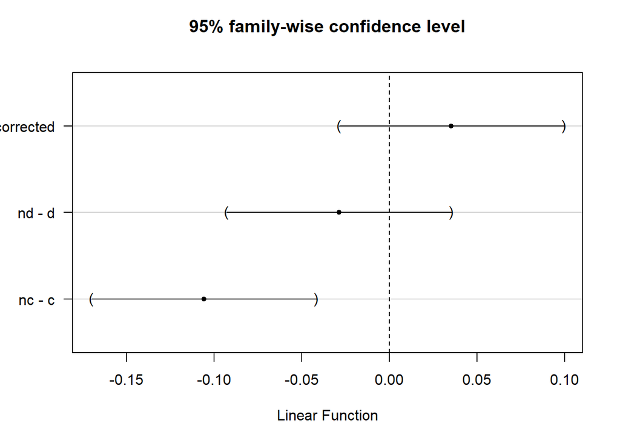

```r
ka = (glht(lm_aov_source,linfct=rbind(k1,k2,k3)))

ka.ci = confint(ka,level = .95)
plot(ka.ci)
```

```r
cohen.d(data_attrib$value~data_attrib$attrib,paired=TRUE,noncentral=TRUE)
```

```
Cohen's d

d estimate: -0.08094143 (negligible)
95 percent confidence interval:
        inf         sup
-0.06328714  0.22538636
```

```r
cohen.d(data_attrib$value~data_attrib$manip_attention,paired=FALSE)
```

```
Cohen's d

d estimate: -0.113739 (negligible)
95 percent confidence interval:
        inf         sup
-0.31780956  0.09033161
```

```r
cohen.d(data_attrib$value~data_attrib$manip_cred,paired=FALSE)
```

```
Cohen's d

d estimate: -0.4117838 (small)
95 percent confidence interval:
       inf        sup
-0.6178392 -0.2057284
```

```r
###Comparaisons multiples pour double interaction
#attention * cred

lm_aov_source = lm(value~manip_cred*manip_attention,data=data_attrib)

tmp <- expand.grid(manip_attention = unique(data_attrib$manip_attention),manip_cred = unique(data_attrib$manip_cred))
X <- model.matrix(~ manip_cred * manip_attention, data = tmp)
glht(lm_aov_source, linfct = X)
```

```
     General Linear Hypotheses

Linear Hypotheses:
       Estimate
1 == 0   0.5012
2 == 0   0.5189
3 == 0   0.5960
4 == 0   0.6359
```

```r
Tukey <- contrMat(table(data_attrib$manip_attention), "Tukey")
K1 <- cbind(Tukey, matrix(0, nrow = nrow(Tukey), ncol = ncol(Tukey)))
rownames(K1) <- paste(levels(data_attrib$manip_cred)[2], rownames(K1), sep = ":")
K2 <- cbind(matrix(0, nrow = nrow(Tukey), ncol = ncol(Tukey)), Tukey)
rownames(K2) <- paste(levels(data_attrib$manip_cred)[1], rownames(K2), sep = ":")
K <- rbind(K1, K2)
colnames(K) <- c(colnames(Tukey), colnames(Tukey))

summary(glht(lm_aov_source, linfct = K %*% X), test = adjusted(type = "bonferroni"))
```

```
     Simultaneous Tests for General Linear Hypotheses

Fit: lm(formula = value ~ manip_cred * manip_attention, data = data_attrib)

Linear Hypotheses:
               Estimate Std. Error t value Pr(>|t|)
nc:nd - d == 0  0.01766    0.03788   0.466    1.000
c:nd - d == 0   0.03991    0.03788   1.053    0.586
(Adjusted p values reported -- bonferroni method)
```

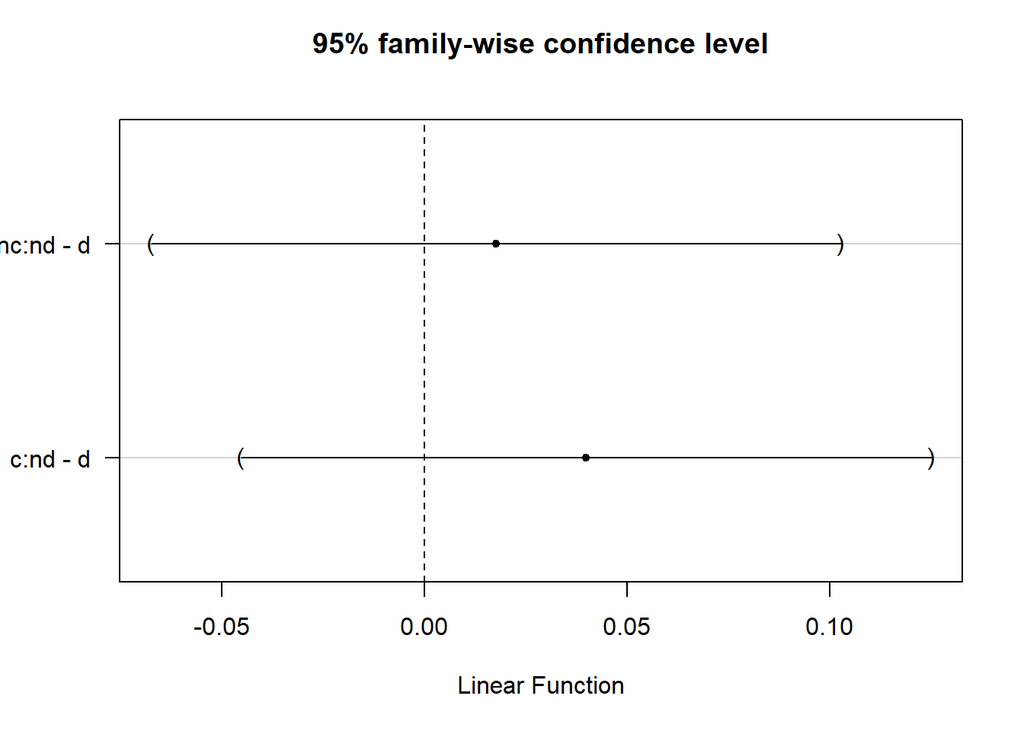

```r
kb = glht(lm_aov_source, linfct = K %*% X)
kb.ci = confint(kb,level=.95)
plot(kb.ci)
```

```r
cohen.d(data_attrib$value[data_attrib$manip_cred=="c"]~data_attrib$manip_attention[data_attrib$manip_cred=="c"],paired=FALSE)
```

```
Cohen's d

d estimate: -0.1526274 (negligible)
95 percent confidence interval:
       inf        sup
-0.4423911  0.1371363
```

```r
cohen.d(data_attrib$value[data_attrib$manip_cred=="nc"]~data_attrib$manip_attention[data_attrib$manip_cred=="nc"],paired=FALSE)
```

```
Cohen's d

d estimate: -0.06913746 (negligible)
95 percent confidence interval:
       inf        sup
-0.3585666  0.2202917
```

```r
###Comparaisons multiples pour double interaction
#attention * liste

lm_aov_source = lm(value~attrib*manip_attention,data=data_attrib)

tmp <- expand.grid(manip_attention = unique(data_attrib$manip_attention),attrib = unique(data_attrib$attrib))
X <- model.matrix(~ attrib * manip_attention, data = tmp)
glht(lm_aov_source, linfct = X)
```

```
     General Linear Hypotheses

Linear Hypotheses:
       Estimate
1 == 0   0.5339
2 == 0   0.5570
3 == 0   0.5623
4 == 0   0.5991
```

```r
Tukey <- contrMat(table(data_attrib$manip_attention), "Tukey")
K1 <- cbind(Tukey, matrix(0, nrow = nrow(Tukey), ncol = ncol(Tukey)))
rownames(K1) <- paste(levels(data_attrib$attrib)[2], rownames(K1), sep = ":")
K2 <- cbind(matrix(0, nrow = nrow(Tukey), ncol = ncol(Tukey)), Tukey)
rownames(K2) <- paste(levels(data_attrib$attrib)[1], rownames(K2), sep = ":")
K <- rbind(K1, K2)
colnames(K) <- c(colnames(Tukey), colnames(Tukey))

summary(glht(lm_aov_source, linfct = K %*% X), test = adjusted(type = "bonferroni"))
```

```
     Simultaneous Tests for General Linear Hypotheses

Fit: lm(formula = value ~ attrib * manip_attention, data = data_attrib)

Linear Hypotheses:
                                         Estimate Std. Error t value
prop_nocred_nocred_corrected:nd - d == 0  0.02313    0.03860   0.599
prop_cred_cred_corrected:nd - d == 0      0.03672    0.03860   0.951
                                         Pr(>|t|)
prop_nocred_nocred_corrected:nd - d == 0    1.000
prop_cred_cred_corrected:nd - d == 0        0.684
(Adjusted p values reported -- bonferroni method)
```

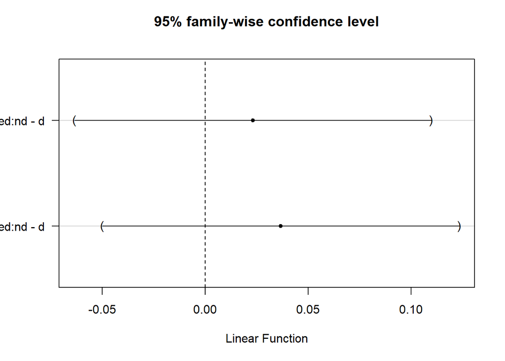

```r
kc = glht(lm_aov_source, linfct = K %*% X)
kc.ci = confint(kc,level=.95)
plot(kc.ci)
```

```r
cohen.d(data_attrib$value[data_attrib$attrib=="prop_cred_cred_corrected"]~data_attrib$manip_attention[data_attrib$attrib=="prop_cred_cred_corrected"],paired=FALSE)
```

```
Cohen's d

d estimate: -0.08451398 (negligible)
95 percent confidence interval:
       inf        sup
-0.3739692  0.2049412
```

```r
cohen.d(data_attrib$value[data_attrib$attrib=="prop_nocred_nocred_corrected"]~data_attrib$manip_attention[data_attrib$attrib=="prop_nocred_nocred_corrected"],paired=FALSE)
```

```
Cohen's d

d estimate: -0.1455453 (negligible)
95 percent confidence interval:
       inf        sup
-0.4352542  0.1441635
```

```r
###Comparaisons multiples pour double interaction
#list * cred
lm_aov_source = lm(value~attrib*manip_cred,data=data_attrib)

tmp <- expand.grid(attrib = unique(data_attrib$attrib),manip_cred = unique(data_attrib$manip_cred))
X <- model.matrix(~ attrib * manip_cred, data = tmp)
glht(lm_aov_source, linfct = X)
```

```
     General Linear Hypotheses

Linear Hypotheses:
       Estimate
1 == 0   0.4230
2 == 0   0.5968
3 == 0   0.6678
4 == 0   0.5646
```

```r
Tukey <- contrMat(table(data_attrib$attrib), "Tukey")
K1 <- cbind(Tukey, matrix(0, nrow = nrow(Tukey), ncol = ncol(Tukey)))
rownames(K1) <- paste(levels(data_attrib$manip_cred)[2], rownames(K1), sep = ":")
K2 <- cbind(matrix(0, nrow = nrow(Tukey), ncol = ncol(Tukey)), Tukey)
rownames(K2) <- paste(levels(data_attrib$manip_cred)[1], rownames(K2), sep = ":")
K <- rbind(K1, K2)
colnames(K) <- c(colnames(Tukey), colnames(Tukey))

summary(glht(lm_aov_source, linfct = K %*% X), test = adjusted(type = "bonferroni"))
```

```
     Simultaneous Tests for General Linear Hypotheses

Fit: lm(formula = value ~ attrib * manip_cred, data = data_attrib)

Linear Hypotheses:
                                                                Estimate
nc:prop_nocred_nocred_corrected - prop_cred_cred_corrected == 0  0.17380
c:prop_nocred_nocred_corrected - prop_cred_cred_corrected == 0  -0.10324
                                                                Std. Error
nc:prop_nocred_nocred_corrected - prop_cred_cred_corrected == 0    0.03646
c:prop_nocred_nocred_corrected - prop_cred_cred_corrected == 0     0.03646
                                                                t value
nc:prop_nocred_nocred_corrected - prop_cred_cred_corrected == 0   4.767
c:prop_nocred_nocred_corrected - prop_cred_cred_corrected == 0   -2.832
                                                                Pr(>|t|)
nc:prop_nocred_nocred_corrected - prop_cred_cred_corrected == 0 5.39e-06
c:prop_nocred_nocred_corrected - prop_cred_cred_corrected == 0   0.00977

nc:prop_nocred_nocred_corrected - prop_cred_cred_corrected == 0 ***
c:prop_nocred_nocred_corrected - prop_cred_cred_corrected == 0  **
---
Signif. codes:  0 '***' 0.001 '**' 0.01 '*' 0.05 '.' 0.1 ' ' 1
(Adjusted p values reported -- bonferroni method)
```

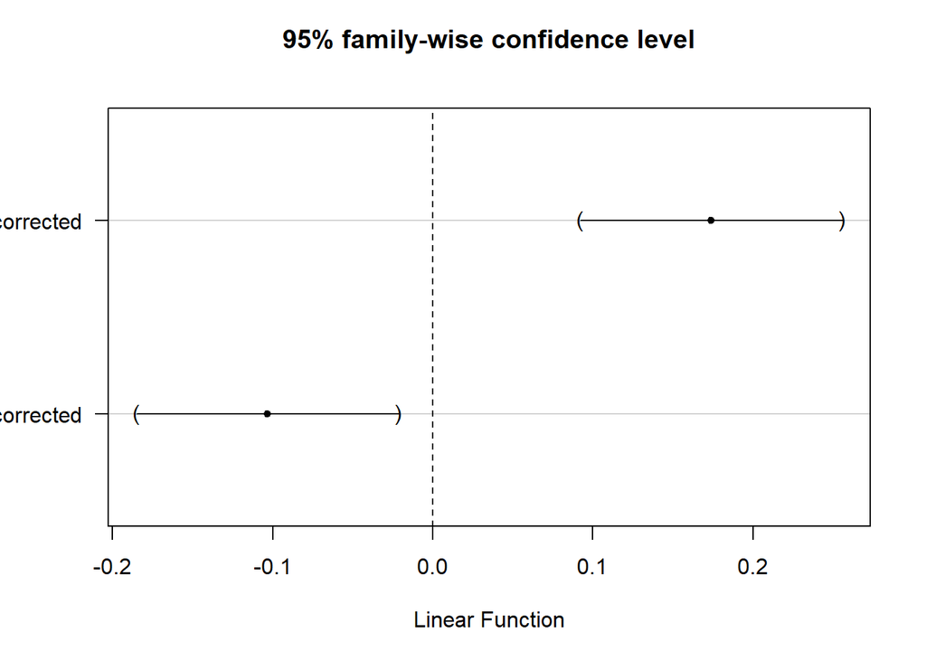

```r
kd = glht(lm_aov_source, linfct = K %*% X)
kd.ci = confint(kd,level=.95)
plot(kd.ci)
```

```r
cohen.d(data_attrib$value[data_attrib$manip_cred=="c"]~data_attrib$attrib[data_attrib$manip_cred=="c"],paired=TRUE)
```

```
Cohen's d

d estimate: 0.2538417 (small)
95 percent confidence interval:
        inf         sup
-0.03664719  0.54433057
```

```r
cohen.d(data_attrib$value[data_attrib$manip_cred=="nc"]~data_attrib$attrib[data_attrib$manip_cred=="nc"],paired=TRUE)
```

```
Cohen's d

d estimate: -0.4121099 (small)
95 percent confidence interval:
       inf        sup
-0.7044909 -0.1197289
```

```r
cohen.d(data_attribc[[2]]$value~data_attribc[[2]]$attrib,paired=TRUE)
```

```
Cohen's d

d estimate: -0.4121099 (small)
95 percent confidence interval:
       inf        sup
-0.7044909 -0.1197289
```

```r
cohen.d(data_attribc[[1]]$value~data_attribc[[1]]$attrib,paired=TRUE)
```

```
Cohen's d

d estimate: 0.2538417 (small)
95 percent confidence interval:
        inf         sup
-0.03664719  0.54433057
```

```r
###Comparaisons multiples pour triple interaction
lm_aov_source = lm(value~attrib*manip_attention*manip_cred,data=data_attrib)

tmp <- expand.grid(attrib = unique(data_attrib$attrib),manip_cred = unique(data_attrib$manip_cred),manip_attention = unique(data_attrib$manip_attention))
X <- model.matrix(~ attrib * manip_attention * manip_cred, data = tmp)
glht(lm_aov_source, linfct = X)
```

```
     General Linear Hypotheses

Linear Hypotheses:
       Estimate
1 == 0   0.4078
2 == 0   0.5946
3 == 0   0.6626
4 == 0   0.5294
5 == 0   0.4386
6 == 0   0.5992
7 == 0   0.6729
8 == 0   0.5990
```

```r
Tukey <- contrMat(table(data_attrib$attrib,data_attrib$manip_attention), "Tukey")
K1 <- cbind(Tukey, matrix(0, nrow = nrow(Tukey), ncol = ncol(Tukey)))
rownames(K1) <- paste(levels(data_attrib$manip_cred)[2], rownames(K1), sep = ":")
K2 <- cbind(matrix(0, nrow = nrow(Tukey), ncol = ncol(Tukey)), Tukey)
rownames(K2) <- paste(levels(data_attrib$manip_cred)[1], rownames(K2), sep = ":")
K <- rbind(K1, K2)
colnames(K) <- c(colnames(Tukey), colnames(Tukey))

summary(glht(lm_aov_source, linfct = K %*% X), test = adjusted(type = "bonferroni"))
```

```
     Simultaneous Tests for General Linear Hypotheses

Fit: lm(formula = value ~ attrib * manip_attention * manip_cred, data = data_attrib)

Linear Hypotheses:
                Estimate Std. Error t value Pr(>|t|)
nc:2 - 1 == 0  0.1867102  0.0514091   3.632  0.00386 **
nc:3 - 1 == 0  0.2547872  0.0516878   4.929 1.51e-05 ***
nc:4 - 1 == 0  0.1216042  0.0516878   2.353  0.23005
nc:3 - 2 == 0  0.0680770  0.0516878   1.317  1.00000
nc:4 - 2 == 0 -0.0651061  0.0516878  -1.260  1.00000
nc:4 - 3 == 0 -0.1331831  0.0519649  -2.563  0.12936
c:2 - 1 == 0   0.1606080  0.0519649   3.091  0.02581 *
c:3 - 1 == 0   0.2343590  0.0516878   4.534 9.43e-05 ***
c:4 - 1 == 0   0.1604301  0.0516878   3.104  0.02472 *
c:3 - 2 == 0   0.0737510  0.0516878   1.427  1.00000
c:4 - 2 == 0  -0.0001779  0.0516878  -0.003  1.00000
c:4 - 3 == 0  -0.0739289  0.0514091  -1.438  1.00000
---
Signif. codes:  0 '***' 0.001 '**' 0.01 '*' 0.05 '.' 0.1 ' ' 1
(Adjusted p values reported -- bonferroni method)
```

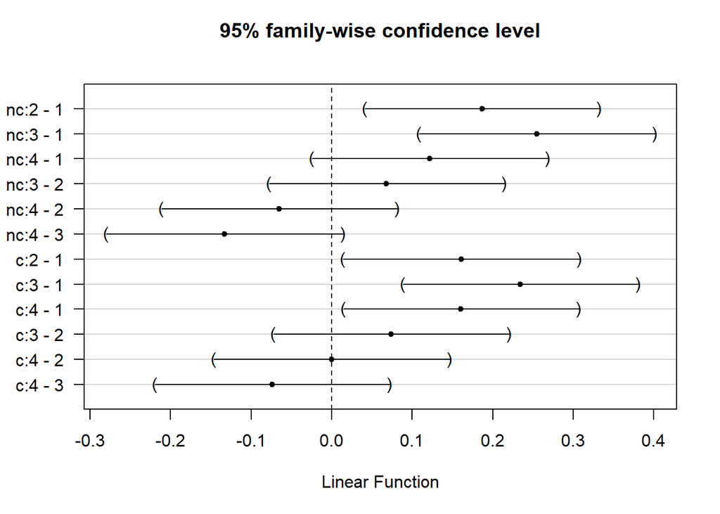

```r
kd = glht(lm_aov_source, linfct = K %*% X)
kd.ci = confint(kd,level=.95)
plot(kd.ci)
```

```r
cohen.d(data_attrib$value~data_attrib$attrib,paired = TRUE)
```

```
Cohen's d

d estimate: -0.08094143 (negligible)
95 percent confidence interval:
       inf        sup
-0.2849307  0.1230478
```

```r
cohen.d(data_attrib$value[data_attrib$manip_cred=="c"]~data_attrib$attrib[data_attrib$manip_cred=="c"],paired = TRUE)
```

```
Cohen's d

d estimate: 0.2538417 (small)
95 percent confidence interval:
        inf         sup
-0.03664719  0.54433057
```

```r
cohen.d(data_attrib$value[data_attrib$manip_cred=="nc"]~data_attrib$attrib[data_attrib$manip_cred=="nc"],paired = TRUE)
```

```
Cohen's d

d estimate: -0.4121099 (small)
95 percent confidence interval:
       inf        sup
-0.7044909 -0.1197289
```

```r
cohen.d(data_attrib$value[data_attrib$manip_cred=="c"]~data_attrib$manip_attention[data_attrib$manip_cred=="c"],paired=FALSE)
```

```
Cohen's d

d estimate: -0.1526274 (negligible)
95 percent confidence interval:
       inf        sup
-0.4423911  0.1371363
```

```r
cohen.d(data_attrib$value[data_attrib$manip_cred=="nc"]~data_attrib$manip_attention[data_attrib$manip_cred=="nc"],paired = FALSE)
```

```
Cohen's d

d estimate: -0.06913746 (negligible)
95 percent confidence interval:
       inf        sup
-0.3585666  0.2202917
```

```r
cohen.d(data_attrib$value[data_attrib$manip_attention=="d"]~data_attrib$manip_cred[data_attrib$manip_attention=="d"],paired = FALSE)
```

```
Cohen's d

d estimate: -0.4547915 (small)
95 percent confidence interval:
       inf        sup
-0.7478504 -0.1617327
```

```r
cohen.d(data_attrib$value[data_attrib$manip_attention=="nd"]~data_attrib$manip_cred[data_attrib$manip_attention=="nd"],paired = FALSE)
```

```
Cohen's d

d estimate: -0.3654782 (small)
95 percent confidence interval:
        inf         sup
-0.65722619 -0.07373012
```

### Effets de la division de l’attention et de la crédibilité sur la reconnaissance

Aucun effet de la division de l’attention n’ayant été trouvé sur le score de mémoire de source, des tests non pré-enregistrés ont été effectués sur le score de reconnaissance afin de fournir davantage de résultats et tester différemment cette hypothèse.

```r
#Compute the 2*2 ANOVA on the recognition score

aov_recog = ezANOVA(data = data
                    , dv = reco_corrected
                    , wid = ppt
                    , between = .(manip_attention,manip_cred)
                    , return_aov = TRUE
                    , detailed = TRUE
                    , type = 3
)
aov_recog
```

```
$ANOVA
                      Effect DFn DFd         SSn   SSd           F
1                (Intercept)   1 182 15.47739489 11.72 240.3485966
2            manip_attention   1 182  0.01422877 11.72   0.2209586
3                 manip_cred   1 182  0.01817873 11.72   0.2822977
4 manip_attention:manip_cred   1 182  0.02062508 11.72   0.3202871
             p p<.05         ges
1 4.191634e-35     * 0.569076347
2 6.388732e-01       0.001212586
3 5.958470e-01       0.001548684
4 5.721323e-01       0.001756727

$`Levene's Test for Homogeneity of Variance`
  DFn DFd        SSn      SSd         F         p p<.05
1   3 182 0.01755323 4.665558 0.2282462 0.8766498

$aov
Call:
   aov(formula = formula(aov_formula), data = data)

Terms:
                manip_attention manip_cred manip_attention:manip_cred
Sum of Squares         0.013887   0.018179                   0.020625
Deg. of Freedom               1          1                          1
                Residuals
Sum of Squares  11.720001
Deg. of Freedom       182

Residual standard error: 0.2537629
Estimated effects may be unbalanced
```

```r
cohen.d(data$reco_corrected~data$manip_attention,paired=FALSE)
```

```
Cohen's d

d estimate: 0.0683595 (negligible)
95 percent confidence interval:
      inf       sup
-0.221051  0.357770
```

```r
cohen.d(data$reco_corrected~data$manip_cred,paired=FALSE)
```

```
Cohen's d

d estimate: -0.07748711 (negligible)
95 percent confidence interval:
       inf        sup
-0.3669217  0.2119475
```

```r
###Comparaisons multiples pour chaque variable
lm_aov_reco = lm(reco_corrected~manip_attention+manip_cred,data=data)

k1 = glht(lm_aov_reco, mcp(manip_attention = "Tukey"))$linfct
k2 = glht(lm_aov_reco, mcp(manip_cred = "Tukey"))$linfct
summary(glht(lm_aov_reco,linfct=rbind(k1,k2)), test = adjusted(type = "bonferroni"))
```

```
     Simultaneous Tests for General Linear Hypotheses

Fit: lm(formula = reco_corrected ~ manip_attention + manip_cred, data = data)

Linear Hypotheses:
            Estimate Std. Error t value Pr(>|t|)
nd - d == 0  0.01749    0.03715   0.471        1
nc - c == 0 -0.01977    0.03715  -0.532        1
(Adjusted p values reported -- bonferroni method)
```

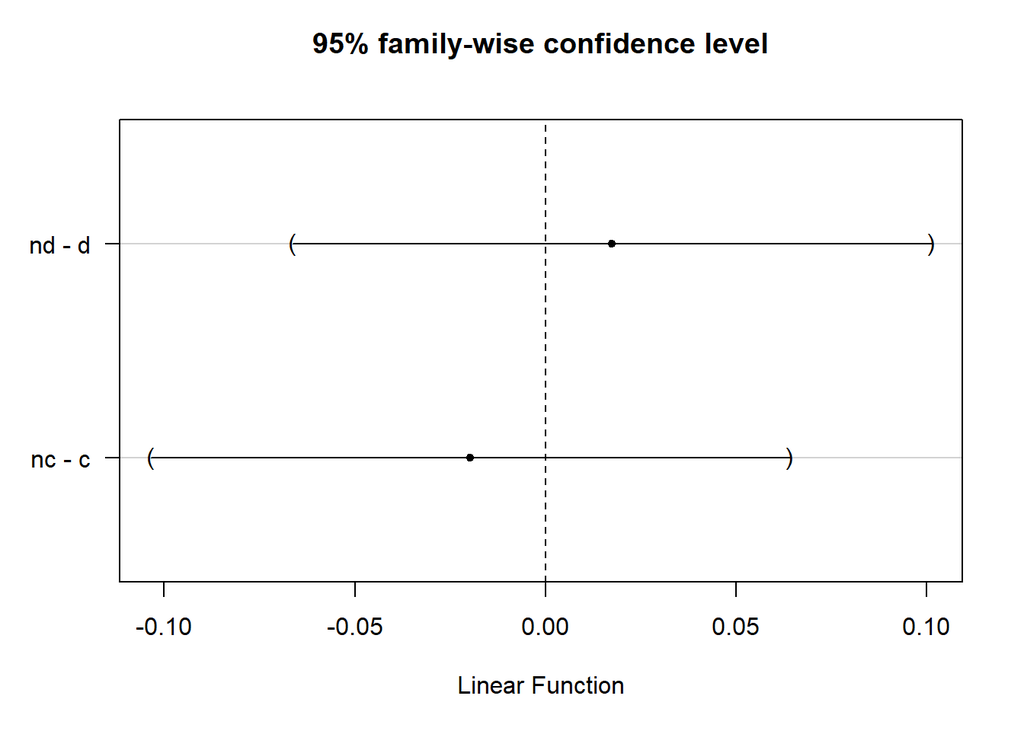

```r
ka = (glht(lm_aov_reco,linfct=rbind(k1,k2)))

ka.ci = confint(ka,level = .95)
plot(ka.ci)
```

```r
###Comparaisons multiples pour double interaction
#attention * cred
lm_aov_reco = lm(reco_corrected~manip_attention*manip_cred,data=data)

tmp <- expand.grid(manip_attention = unique(data$manip_attention),manip_cred = unique(data$manip_cred))
X <- model.matrix(~ manip_attention * manip_cred, data = tmp)
glht(lm_aov_reco, linfct = X)
```

```
     General Linear Hypotheses

Linear Hypotheses:
       Estimate
1 == 0   0.2979
2 == 0   0.2593
3 == 0   0.2966
4 == 0   0.3002
```

```r
Tukey <- contrMat(table(data$manip_attention), "Tukey")
K1 <- cbind(Tukey, matrix(0, nrow = nrow(Tukey), ncol = ncol(Tukey)))
rownames(K1) <- paste(levels(data$manip_cred)[2], rownames(K1), sep = ":")
K2 <- cbind(matrix(0, nrow = nrow(Tukey), ncol = ncol(Tukey)), Tukey)
rownames(K2) <- paste(levels(data$manip_cred)[1], rownames(K2), sep = ":")
K <- rbind(K1, K2)
colnames(K) <- c(colnames(Tukey), colnames(Tukey))

summary(glht(lm_aov_reco, linfct = K %*% X), test = adjusted(type = "bonferroni"))
```

```
     Simultaneous Tests for General Linear Hypotheses

Fit: lm(formula = reco_corrected ~ manip_attention * manip_cred, data = data)

Linear Hypotheses:
                Estimate Std. Error t value Pr(>|t|)
nc:nd - d == 0 -0.038556   0.052631  -0.733     0.93
c:nd - d == 0   0.003568   0.052631   0.068     1.00
(Adjusted p values reported -- bonferroni method)
```

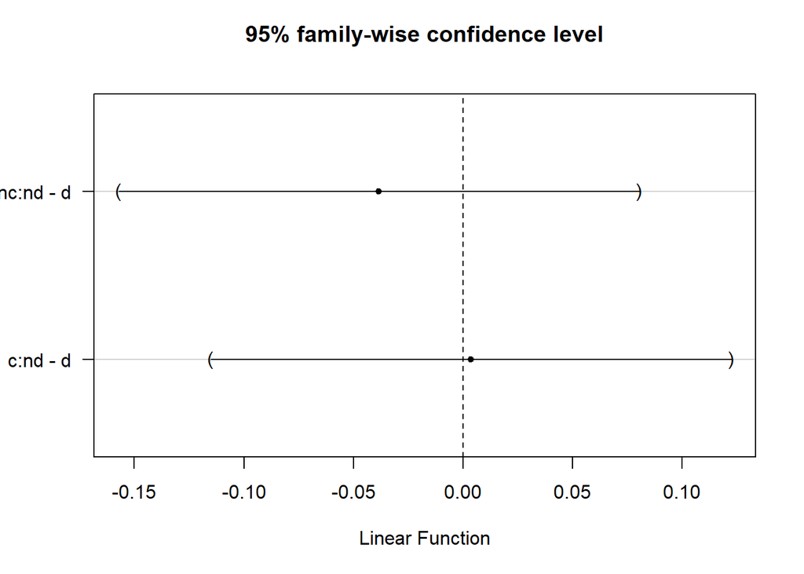

```r
kc = glht(lm_aov_reco, linfct = K %*% X)
kc.ci = confint(kc,level=.95)
plot(kc.ci)
```

```r
cohen.d(data$reco_corrected[data$manip_cred=="c"]~data$manip_attention[data$manip_cred=="c"],paired=FALSE)
```

```
Cohen's d

d estimate: -0.01407707 (negligible)
95 percent confidence interval:
       inf        sup
-0.4260614  0.3979073
```

```r
cohen.d(data$reco_corrected[data$manip_cred=="nc"]~data$manip_attention[data$manip_cred=="nc"],paired=FALSE)
```

```
Cohen's d

d estimate: 0.1513907 (negligible)
95 percent confidence interval:
       inf        sup
-0.2611782  0.5639596
```

Les résultats montrent clairement que les effets sont très petits, même négligeables.

### Recollection et familiarité en fonction de la division de l’attention lorsque la crédibilité est manipulée

Lorsque la crédibilité est manipulée, des indices de recollection et de familiarité peuvent être calculés. J’ai donc réalisé deux t test pour groupes indépendants pour tester l’effet de la division de l’attention sur ces deux scores.

```r
#Compute the independent samples t tests on the recollection and familiarity scores.
##First, compute these scores. Correct the recollection score with negative scores set to 0.

data_cred$R = data_cred$prop_true_cred - data_cred$prop_true_nocred
data_cred$F = data_cred$prop_true_nocred / (1 - data_cred$R)
for(i in 1:93){

  if (data_cred$R[i]<0) {
    data_cred$R[i]=0
  }
}
t.test(data_cred$R~data_cred$manip_attention,paired=FALSE,var.equal=TRUE)
```

```
    Two Sample t-test

data:  data_cred$R by data_cred$manip_attention
t = 0.93619, df = 91, p-value = 0.3517
alternative hypothesis: true difference in means is not equal to 0
95 percent confidence interval:
 -0.04217553  0.11737045
sample estimates:
 mean in group d mean in group nd
       0.1990881        0.1614907
```

```r
cohen.d(data_cred$R~data_cred$manip_attention,paired=FALSE)
```

```
Cohen's d

d estimate: -0.1944869 (negligible)
95 percent confidence interval:
       inf        sup
-0.6074389  0.2184650
```

```r
t.test(data_cred$F~data_cred$manip_attention,paired=FALSE,var.equal=TRUE)
```

```
    Two Sample t-test

data:  data_cred$F by data_cred$manip_attention
t = -0.23923, df = 91, p-value = 0.8115
alternative hypothesis: true difference in means is not equal to 0
95 percent confidence interval:
 -0.06873950  0.05396213
sample estimates:
 mean in group d mean in group nd
       0.5671727        0.5745614
```

```r
cohen.d(data_cred$F~data_cred$manip_attention,paired=FALSE)
```

```
Cohen's d

d estimate: 0.04969337 (negligible)
95 percent confidence interval:
       inf        sup
-0.3623494  0.4617362
```

### Effet de vérité

J’ai réalisé une ANOVA 2(liste) x 2(attention) x 2(crédibilité) sur le score de jugement de vérité.

```r
#Compute the 2*2*2 ANOVA on the truth judgement score

aov_truthjudg = ezANOVA(data = data_list
                              , dv = value
                              , wid = ppt
                              , within = list
                              , between = .(manip_attention,manip_cred)
                              , return_aov = TRUE
                              , type = 3

)
aov_truthjudg
```

```
$ANOVA
                           Effect DFn DFd          F            p p<.05
2                 manip_attention   1 182  1.4330788 2.328196e-01
3                      manip_cred   1 182  0.1684599 6.819670e-01
5                            list   1 182 19.0820118 2.099154e-05     *
4      manip_attention:manip_cred   1 182  4.9370285 2.751951e-02     *
6            manip_attention:list   1 182  0.1817824 6.703497e-01
7                 manip_cred:list   1 182 21.5925564 6.451673e-06     *
8 manip_attention:manip_cred:list   1 182  4.5629881 3.400629e-02     *
           ges
2 0.0058230822
3 0.0006880448
5 0.0261530742
4 0.0197792000
6 0.0002557695
7 0.0294924511
8 0.0063808302

$aov

Call:
aov(formula = formula(aov_formula), data = data)

Grand Mean: 0.06931644

Stratum 1: ppt

Terms:
                manip_attention manip_cred manip_attention:manip_cred
Sum of Squares         0.089985   0.010655                   0.312266
Deg. of Freedom               1          1                          1
                Residuals
Sum of Squares  11.511455
Deg. of Freedom       182

Residual standard error: 0.251495
3 out of 6 effects not estimable
Estimated effects may be unbalanced

Stratum 2: ppt:list

Terms:
                    list manip_attention:list manip_cred:list
Sum of Squares  0.420027             0.003086        0.470275
Deg. of Freedom        1                    1               1
                manip_attention:manip_cred:list Residuals
Sum of Squares                         0.099380  3.963866
Deg. of Freedom                               1       182

Residual standard error: 0.1475787
Estimated effects may be unbalanced
```

Parmi les effets principaux, seul l’effet de la liste ressort. Il est qualifié par un effet d’interaction de magnitude comparable avec la crédibilité. En outre, la division de l’attention et la crédibilité intéragissent significativement sur le score de jugement de vérité. Enfin, ces doubles interactions sont qualifiées par une triple interaction significative, dont la taille est plus faible que celle visée dans l’analyse de puissance statistique. Des comparaisons multiples et des ANOVAs séparées dans les deux conditions de crédibilité vont permettre d’approfondir ces résultats.

```r
#Based on the previous ANOVA, compute the multiple comparisons and effect sizes

###Comparaisons multiples pour chaque variable
lm_aov_truth = lm(value~list+manip_attention+manip_cred,data=data_list)

k1 = glht(lm_aov_truth, mcp(list = "Tukey"))$linfct
k2 = glht(lm_aov_truth, mcp(manip_attention = "Tukey"))$linfct
k3 = glht(lm_aov_truth, mcp(manip_cred = "Tukey"))$linfct
summary(glht(lm_aov_truth,linfct=rbind(k1,k2,k3)), test = adjusted(type = "bonferroni"))
```

```
     Simultaneous Tests for General Linear Hypotheses

Fit: lm(formula = value ~ list + manip_attention + manip_cred, data = data_list)

Linear Hypotheses:
                                           Estimate Std. Error t value
diff_prop_nocred_n - diff_prop_cred_n == 0 -0.06720    0.02186  -3.074
nd - d == 0                                -0.03122    0.02187  -1.428
nc - c == 0                                 0.01070    0.02187   0.490
                                           Pr(>|t|)
diff_prop_nocred_n - diff_prop_cred_n == 0  0.00681 **
nd - d == 0                                 0.46252
nc - c == 0                                 1.00000
---
Signif. codes:  0 '***' 0.001 '**' 0.01 '*' 0.05 '.' 0.1 ' ' 1
(Adjusted p values reported -- bonferroni method)
```

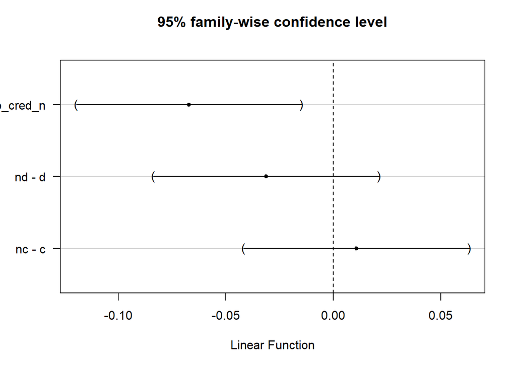

```r
ka = (glht(lm_aov_truth,linfct=rbind(k1,k2,k3)))

ka.ci = confint(ka,level = .95)
plot(ka.ci)
```

```r
cohen.d(data_list$value~data_list$list,paired=TRUE,noncentral=TRUE)
```

```
Cohen's d

d estimate: 0.3034607 (small)
95 percent confidence interval:
      inf       sup
-0.451279 -0.156493
```

```r
cohen.d(data_list$value~data_list$manip_attention,paired=FALSE)
```

```
Cohen's d

d estimate: -0.146018 (negligible)
95 percent confidence interval:
        inf         sup
-0.35019537  0.05815929
```

```r
cohen.d(data_list$value~data_list$manip_cred,paired=FALSE)
```

```
Cohen's d

d estimate: 0.04855716 (negligible)
95 percent confidence interval:
       inf        sup
-0.1553787  0.2524930
```

```r
###Comparaisons multiples pour double interaction
#attention * cred
lm_aov_truth = lm(value~manip_cred*manip_attention,data=data_list)

tmp <- expand.grid(manip_attention = unique(data_list$manip_attention),manip_cred = unique(data_list$manip_cred))
X <- model.matrix(~ manip_cred*manip_attention, data = tmp)
glht(lm_aov_truth, linfct = X)
```

```
     General Linear Hypotheses

Linear Hypotheses:
       Estimate
1 == 0  0.03040
2 == 0  0.11957
3 == 0  0.07764
4 == 0  0.05091
```

```r
Tukey <- contrMat(table(data_list$manip_attention), "Tukey")
K1 <- cbind(Tukey, matrix(0, nrow = nrow(Tukey), ncol = ncol(Tukey)))
rownames(K1) <- paste(levels(data_list$manip_cred)[2], rownames(K1), sep = ":")
K2 <- cbind(matrix(0, nrow = nrow(Tukey), ncol = ncol(Tukey)), Tukey)
rownames(K2) <- paste(levels(data_list$manip_cred)[1],rownames(K2), sep = ":")
K <- rbind(K1, K2)
colnames(K) <- c(colnames(Tukey), colnames(Tukey))

summary(glht(lm_aov_truth, linfct = K %*% X), test = adjusted(type = "bonferroni"))
```

```
     Simultaneous Tests for General Linear Hypotheses

Fit: lm(formula = value ~ manip_cred * manip_attention, data = data_list)

Linear Hypotheses:
               Estimate Std. Error t value Pr(>|t|)
nc:nd - d == 0  0.08917    0.03102   2.874  0.00857 **
c:nd - d == 0  -0.02673    0.03102  -0.862  0.77902
---
Signif. codes:  0 '***' 0.001 '**' 0.01 '*' 0.05 '.' 0.1 ' ' 1
(Adjusted p values reported -- bonferroni method)
```

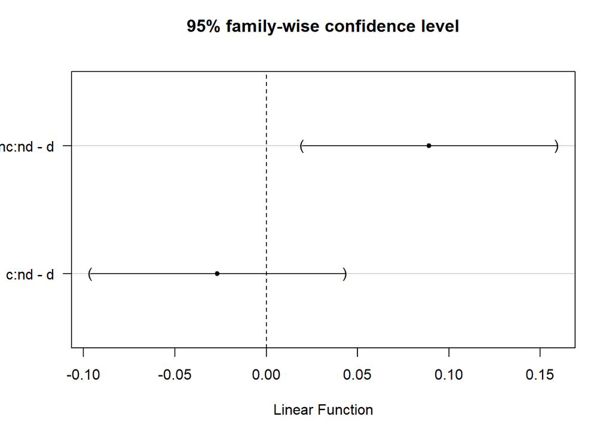

```r
kb = glht(lm_aov_truth, linfct = K %*% X)
kb.ci = confint(kb,level=.95)
plot(kb.ci)
```

```r
cohen.d(data_list$value[data_list$manip_cred=="c"]~data_list$manip_attention[data_list$manip_cred=="c"],paired=FALSE)
```

```
Cohen's d

d estimate: 0.1123824 (negligible)
95 percent confidence interval:
       inf        sup
-0.1771887  0.4019534
```

```r
cohen.d(data_list$value[data_list$manip_cred=="nc"]~data_list$manip_attention[data_list$manip_cred=="nc"],paired=FALSE)
```

```
Cohen's d

d estimate: -0.4909346 (small)
95 percent confidence interval:
       inf        sup
-0.7846030 -0.1972661
```

```r
###Comparaisons multiples pour double interaction
#attention * liste
lm_aov_truth = lm(value~list*manip_attention,data=data_list)

tmp <- expand.grid(manip_attention = unique(data_list$manip_attention),list = unique(data_list$list))
X <- model.matrix(~ list * manip_attention, data = tmp)
glht(lm_aov_truth, linfct = X)
```

```
     General Linear Hypotheses

Linear Hypotheses:
       Estimate
1 == 0  0.09025
2 == 0  0.11559
3 == 0  0.01728
4 == 0  0.05415
```

```r
Tukey <- contrMat(table(data_list$manip_attention), "Tukey")
K1 <- cbind(Tukey, matrix(0, nrow = nrow(Tukey), ncol = ncol(Tukey)))
rownames(K1) <- paste(levels(data_list$list)[2], rownames(K1), sep = ":")
K2 <- cbind(matrix(0, nrow = nrow(Tukey), ncol = ncol(Tukey)), Tukey)
rownames(K2) <- paste(levels(data_list$list)[1], rownames(K2), sep = ":")
K <- rbind(K1, K2)
colnames(K) <- c(colnames(Tukey), colnames(Tukey))

summary(glht(lm_aov_truth, linfct = K %*% X), test = adjusted(type = "bonferroni"))
```

```
     Simultaneous Tests for General Linear Hypotheses

Fit: lm(formula = value ~ list * manip_attention, data = data_list)

Linear Hypotheses:
                               Estimate Std. Error t value Pr(>|t|)
diff_prop_nocred_n:nd - d == 0  0.02535    0.03093   0.820    0.826
diff_prop_cred_n:nd - d == 0    0.03687    0.03093   1.192    0.468
(Adjusted p values reported -- bonferroni method)
```

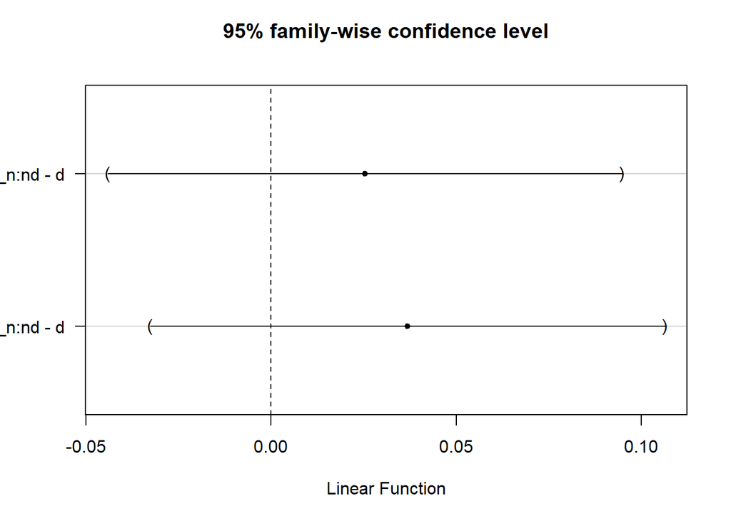

```r
kc = glht(lm_aov_truth, linfct = K %*% X)
kc.ci = confint(kc,level=.95)
plot(kc.ci)
```

```r
cohen.d(data_list$value[data_list$list=="diff_prop_cred_n"]~data_list$manip_attention[data_list$list=="diff_prop_cred_n"],paired=FALSE)
```

```
Cohen's d

d estimate: -0.1254121 (negligible)
95 percent confidence interval:
       inf        sup
-0.4150224  0.1641982
```

```r
cohen.d(data_list$value[data_list$list=="diff_prop_nocred_n"]~data_list$manip_attention[data_list$list=="diff_prop_nocred_n"],paired=FALSE)
```

```
Cohen's d

d estimate: -0.1680751 (negligible)
95 percent confidence interval:
       inf        sup
-0.4579115  0.1217613
```

```r
###Comparaisons multiples pour double interaction
#list * cred

lm_aov_truth = lm(value~list*manip_cred,data=data_list)

tmp <- expand.grid(list = unique(data_list$list),manip_cred = unique(data_list$manip_cred))
X <- model.matrix(~ list * manip_cred, data = tmp)
glht(lm_aov_truth, linfct = X)
```

```
     General Linear Hypotheses

Linear Hypotheses:
        Estimate
1 == 0  0.072581
2 == 0  0.076421
3 == 0  0.133257
4 == 0 -0.004992
```

```r
Tukey <- contrMat(table(data_list$list), "Tukey")
K1 <- cbind(Tukey, matrix(0, nrow = nrow(Tukey), ncol = ncol(Tukey)))
rownames(K1) <- paste(levels(data_list$manip_cred)[2], rownames(K1), sep = ":")
K2 <- cbind(matrix(0, nrow = nrow(Tukey), ncol = ncol(Tukey)), Tukey)
rownames(K2) <- paste(levels(data_list$manip_cred)[1], rownames(K2), sep = ":")
K <- rbind(K1, K2)
colnames(K) <- c(colnames(Tukey), colnames(Tukey))

summary(glht(lm_aov_truth, linfct = K %*% X), test = adjusted(type = "bonferroni"))
```

```
     Simultaneous Tests for General Linear Hypotheses

Fit: lm(formula = value ~ list * manip_cred, data = data_list)

Linear Hypotheses:
                                              Estimate Std. Error t value
nc:diff_prop_nocred_n - diff_prop_cred_n == 0  0.00384    0.03056   0.126
c:diff_prop_nocred_n - diff_prop_cred_n == 0  -0.13825    0.03056  -4.524
                                              Pr(>|t|)
nc:diff_prop_nocred_n - diff_prop_cred_n == 0        1
c:diff_prop_nocred_n - diff_prop_cred_n == 0  1.64e-05 ***
---
Signif. codes:  0 '***' 0.001 '**' 0.01 '*' 0.05 '.' 0.1 ' ' 1
(Adjusted p values reported -- bonferroni method)
```

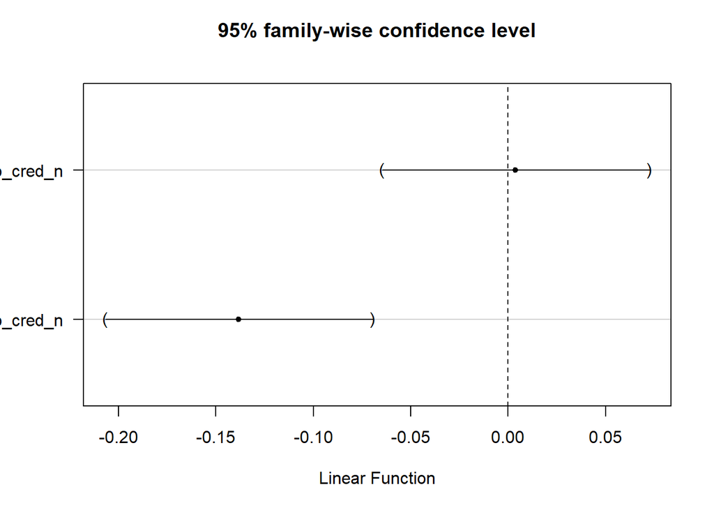

```r
kd = glht(lm_aov_truth, linfct = K %*% X)
kd.ci = confint(kd,level=.95)
plot(kd.ci)
```

```r
cohen.d(data_list$value[data_list$manip_cred=="c"]~data_list$list[data_list$manip_cred=="c"],paired=TRUE)
```

```
Cohen's d

d estimate: 0.5671063 (medium)
95 percent confidence interval:
      inf       sup
0.2720220 0.8621907
```

```r
cohen.d(data_list$value[data_list$manip_cred=="nc"]~data_list$list[data_list$manip_cred=="nc"],paired=TRUE)
```

```
Cohen's d

d estimate: -0.02255494 (negligible)
95 percent confidence interval:
       inf        sup
-0.3118902  0.2667803
```

```r
###Comparaisons multiples pour triple interaction
lm_aov_truth = lm(value~list*manip_attention*manip_cred,data=data_list)

tmp <- expand.grid(list = unique(data_list$list),manip_cred = unique(data_list$manip_cred),manip_attention = unique(data_list$manip_attention))
X <- model.matrix(~ list * manip_attention * manip_cred, data = tmp)
glht(lm_aov_truth, linfct = X)
```

```
     General Linear Hypotheses

Linear Hypotheses:
       Estimate
1 == 0  0.04787
2 == 0  0.01292
3 == 0  0.13354
4 == 0  0.02174
5 == 0  0.09783
6 == 0  0.14130
7 == 0  0.13298
8 == 0 -0.03116
```

```r
Tukey <- contrMat(table(data_list$list,data_list$manip_attention), "Tukey")
K1 <- cbind(Tukey, matrix(0, nrow = nrow(Tukey), ncol = ncol(Tukey)))
rownames(K1) <- paste(levels(data_list$manip_cred)[2], rownames(K1), sep = ":")
K2 <- cbind(matrix(0, nrow = nrow(Tukey), ncol = ncol(Tukey)), Tukey)
rownames(K2) <- paste(levels(data_list$manip_cred)[1], rownames(K2), sep = ":")
K <- rbind(K1, K2)
colnames(K) <- c(colnames(Tukey), colnames(Tukey))

summary(glht(lm_aov_truth, linfct = K %*% X), test = adjusted(type = "bonferroni"))
```

```
     Simultaneous Tests for General Linear Hypotheses

Fit: lm(formula = value ~ list * manip_attention * manip_cred, data = data_list)

Linear Hypotheses:
               Estimate Std. Error t value Pr(>|t|)
nc:2 - 1 == 0 -0.034954   0.042534  -0.822 1.000000
nc:3 - 1 == 0  0.085668   0.042764   2.003 0.550691
nc:4 - 1 == 0 -0.026133   0.042764  -0.611 1.000000
nc:3 - 2 == 0  0.120622   0.042764   2.821 0.060667 .
nc:4 - 2 == 0  0.008821   0.042764   0.206 1.000000
nc:4 - 3 == 0 -0.111801   0.042994  -2.600 0.116288
c:2 - 1 == 0   0.043478   0.042994   1.011 1.000000
c:3 - 1 == 0   0.035153   0.042764   0.822 1.000000
c:4 - 1 == 0  -0.128981   0.042764  -3.016 0.032886 *
c:3 - 2 == 0  -0.008326   0.042764  -0.195 1.000000
c:4 - 2 == 0  -0.172459   0.042764  -4.033 0.000806 ***
c:4 - 3 == 0  -0.164134   0.042534  -3.859 0.001617 **
---
Signif. codes:  0 '***' 0.001 '**' 0.01 '*' 0.05 '.' 0.1 ' ' 1
(Adjusted p values reported -- bonferroni method)
```

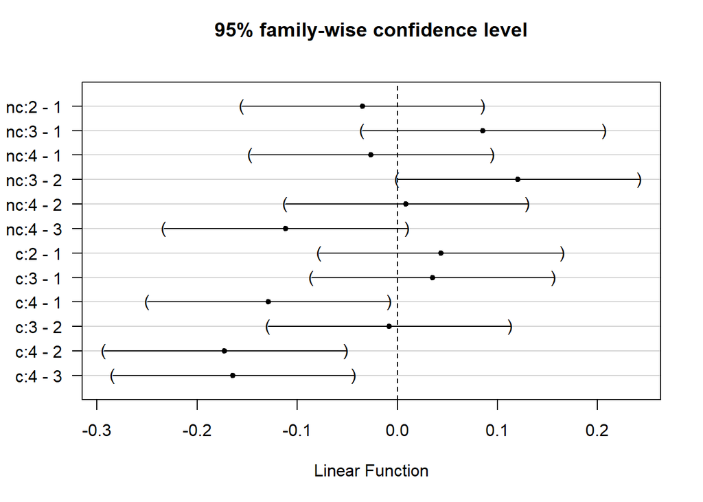

```r
kd = glht(lm_aov_truth, linfct = K %*% X)
kd.ci = confint(kd,level=.95)
plot(kd.ci)
```

```r
cohen.d(data_list$value,data_list$list,paired = TRUE)
```

```
Cohen's d

d estimate: 0.3034607 (small)
95 percent confidence interval:
       inf        sup
0.09838466 0.50853669
```

```r
cohen.d(data_list$value[data_list$manip_cred=="c"],data_list$list[data_list$manip_cred=="c"],paired = TRUE)
```

```
Cohen's d

d estimate: 0.5671063 (medium)
95 percent confidence interval:
      inf       sup
0.2720220 0.8621907
```

```r
cohen.d(data_list$value[data_list$manip_cred=="nc"],data_list$list[data_list$manip_cred=="nc"],paired = TRUE)
```

```
Cohen's d

d estimate: -0.02255494 (negligible)
95 percent confidence interval:
       inf        sup
-0.3118902  0.2667803
```

```r
cohen.d(data_list$value[data_list$manip_cred=="c"],data_list$manip_attention[data_list$manip_cred=="c"])
```

```
Cohen's d

d estimate: 0.1123824 (negligible)
95 percent confidence interval:
       inf        sup
-0.1771887  0.4019534
```

```r
cohen.d(data_list$value[data_list$manip_cred=="nc"],data_list$manip_attention[data_list$manip_cred=="nc"])
```

```
Cohen's d

d estimate: -0.4909346 (small)
95 percent confidence interval:
       inf        sup
-0.7846030 -0.1972661
```

```r
cohen.d(data_list$value[data_list$manip_attention=="d"],data_list$manip_cred[data_list$manip_attention=="d"])
```

```
Cohen's d

d estimate: 0.3113347 (small)
95 percent confidence interval:
       inf        sup
0.02024452 0.60242482
```

```r
cohen.d(data_list$value[data_list$manip_attention=="nd"],data_list$manip_cred[data_list$manip_attention=="nd"])
```

```
Cohen's d

d estimate: -0.2335304 (small)
95 percent confidence interval:
        inf         sup
-0.52385760  0.05679682
```

Le score de jugement de vérité est en moyenne plus élevé dans la liste 1/ crédible que non crédible. Cette taille d’effet est petite. Concernant l’interaction crédibilité * attention, les résultats montrent que l’effet de la division de l’attention sur le score de vérité est très faible et non significatif lorsque la crédibilité est manipulée. À l’inverse, lorsque la crédibilité n’est pas manipulée, cet effet est moyen et significatif.

J’ai réalisé une ANOVA 2(list)*2(attention) sur le score de jugement de vérité dans chaque condition de la crédibilité. Elles sont présentées ci-dessous avec les comparaisons multiples et les tailles des effets associés.

```r
#Compute the 2*2 ANOVAs in each credibility condition
##First, the ANOVA with credibility, multiple comparisons and effect sizes

aov_truthjudg_c = ezANOVA(data = data_listc[[1]]
                        , dv = value
                        , wid = ppt
                        , within = list
                        , between = manip_attention
                        , return_aov = TRUE
                        , type = 3

)
aov_truthjudg_c
```

```
$ANOVA
                Effect DFn DFd          F            p p<.05         ges
2      manip_attention   1  91  0.4447435 5.065293e-01       0.003484835
3                 list   1  91 29.8079947 4.100871e-07     * 0.085237475
4 manip_attention:list   1  91  1.0721663 3.032005e-01       0.003340400

$aov

Call:
aov(formula = formula(aov_formula), data = data)

Grand Mean: 0.0641321

Stratum 1: ppt

Terms:
                manip_attention Residuals
Sum of Squares         0.033215  6.796169
Deg. of Freedom               1        91

Residual standard error: 0.2732822
1 out of 2 effects not estimable
Estimated effects are balanced

Stratum 2: ppt:list

Terms:
                     list manip_attention:list Residuals
Sum of Squares  0.8887426            0.0318336 2.7018728
Deg. of Freedom         1                    1        91

Residual standard error: 0.1723105
Estimated effects may be unbalanced
```

```r
###Comparaisons multiples pour chaque variable
lm_aov_truthc = lm(value~list+manip_attention,data=data_listc[[1]])

k1 = glht(lm_aov_truthc, mcp(list = "Tukey"))$linfct
k2 = glht(lm_aov_truthc, mcp(manip_attention = "Tukey"))$linfct
summary(glht(lm_aov_truthc,linfct=rbind(k1,k2)), test = adjusted(type = "bonferroni"))
```

```
     Simultaneous Tests for General Linear Hypotheses

Fit: lm(formula = value ~ list + manip_attention, data = data_listc[[1]])

Linear Hypotheses:
                                           Estimate Std. Error t value
diff_prop_nocred_n - diff_prop_cred_n == 0 -0.13825    0.03347  -4.131
nd - d == 0                                 0.02673    0.03347   0.799
                                           Pr(>|t|)
diff_prop_nocred_n - diff_prop_cred_n == 0  0.00011 ***
nd - d == 0                                 0.85108
---
Signif. codes:  0 '***' 0.001 '**' 0.01 '*' 0.05 '.' 0.1 ' ' 1
(Adjusted p values reported -- bonferroni method)
```

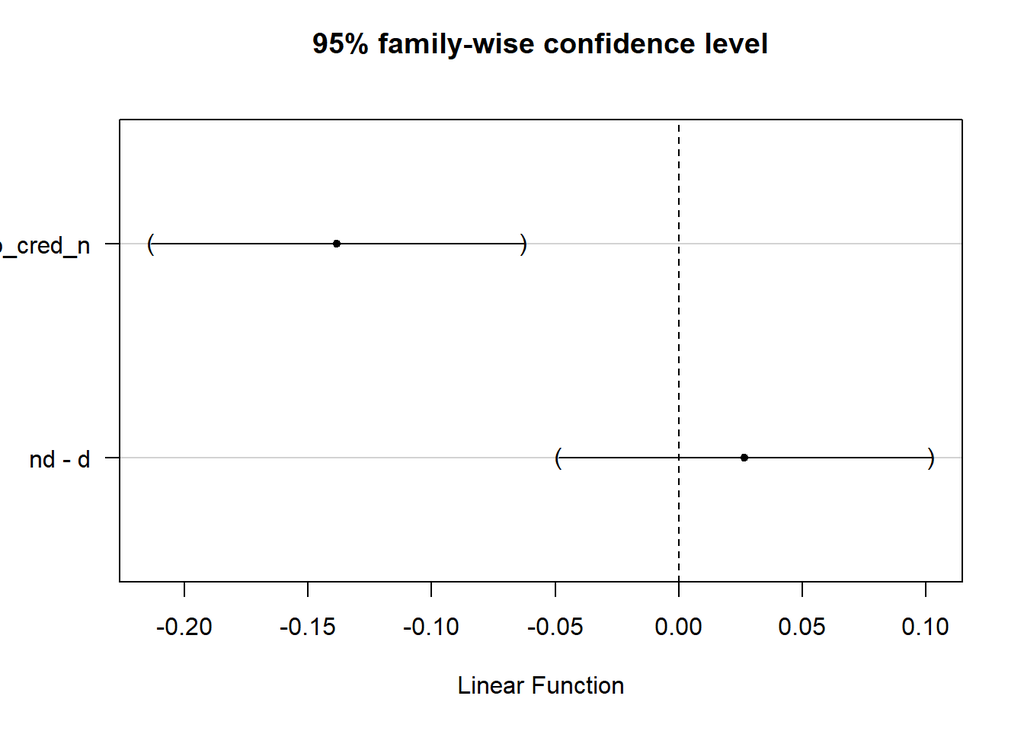

```r
ka = (glht(lm_aov_truthc,linfct=rbind(k1,k2)))

ka.ci = confint(ka,level = .95)
plot(ka.ci)
```

```r
cohen.d(data_listc[[1]]$value~data_listc[[1]]$list,paired=TRUE)
```

```
Cohen's d

d estimate: 0.5671063 (medium)
95 percent confidence interval:
      inf       sup
0.2720220 0.8621907
```

```r
cohen.d(data_listc[[1]]$value~data_listc[[1]]$manip_attention,paired=FALSE)
```

```
Cohen's d

d estimate: 0.1123824 (negligible)
95 percent confidence interval:
       inf        sup
-0.1771887  0.4019534
```

```r
###Comparaisons multiples pour double interaction
#attention * liste
lm_aov_truthc = lm(value~list*manip_attention,data=data_listc[[1]])

tmp <- expand.grid(manip_attention = unique(data_listc[[1]]$manip_attention),list = unique(data_listc[[1]]$list))
X <- model.matrix(~ list * manip_attention, data = tmp)
glht(lm_aov_truthc, linfct = X)
```

```
     General Linear Hypotheses

Linear Hypotheses:
       Estimate
1 == 0  0.13354
2 == 0  0.13298
3 == 0  0.02174
4 == 0 -0.03116
```

```r
Tukey <- contrMat(table(data_listc[[1]]$manip_attention), "Tukey")
K1 <- cbind(Tukey, matrix(0, nrow = nrow(Tukey), ncol = ncol(Tukey)))
rownames(K1) <- paste(levels(data_listc[[1]]$list)[2], rownames(K1), sep = ":")
K2 <- cbind(matrix(0, nrow = nrow(Tukey), ncol = ncol(Tukey)), Tukey)
rownames(K2) <- paste(levels(data_listc[[1]]$attrib)[1], rownames(K2), sep = ":")
K <- rbind(K1, K2)
colnames(K) <- c(colnames(Tukey), colnames(Tukey))

summary(glht(lm_aov_truthc, linfct = K %*% X), test = adjusted(type = "bonferroni"))
```

```
     Simultaneous Tests for General Linear Hypotheses

Fit: lm(formula = value ~ list * manip_attention, data = data_listc[[1]])

Linear Hypotheses:
                                 Estimate Std. Error t value Pr(>|t|)
diff_prop_nocred_n:nd - d == 0 -0.0005616  0.0473800  -0.012    1.000
:nd - d == 0                   -0.0528941  0.0473800  -1.116    0.531
(Adjusted p values reported -- bonferroni method)
```

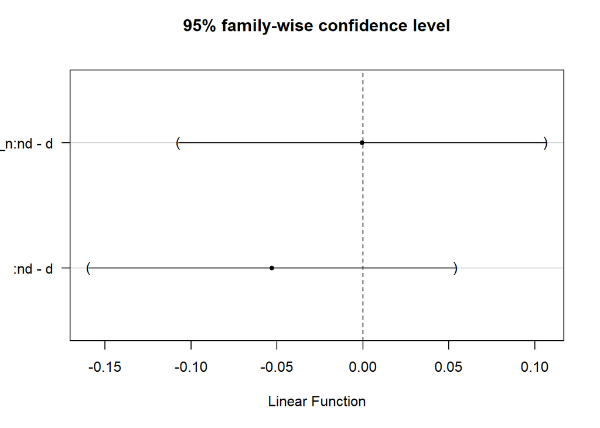

```r
kc = glht(lm_aov_truthc, linfct = K %*% X)
kc.ci = confint(kc,level=.95)
plot(kc.ci)
```

```r
cohen.d(data_listc[[1]]$value[data_listc[[1]]$list=="diff_prop_cred_n"]~data_listc[[1]]$manip_attention[data_listc[[1]]$list=="diff_prop_cred_n"],paired=FALSE)
```

```
Cohen's d

d estimate: 0.002467805 (negligible)
95 percent confidence interval:
       inf        sup
-0.4095116  0.4144472
```